# Finding the cheater, An analysis of chess statistics

### Understanding chess_2

Includes both rated and unrated games. Comlumns stated in the prior section will be ommited.

**Columns**

- victory_status
  - How the game ended
  - Out of time
  - Resign
  - Mate
- Winner
  - who won
- Player ID
  - identifies the player
  - useful for tracking elo over time if provided with time

```python
chess_2.head()
```

|  | Game ID | rated | turns | victory_status | winner | white_id | white_rating | black_id | black_rating | opening_eco |
| --- | --- | --- | --- | --- | --- | --- | --- | --- | --- | --- |
| 0 | TZJHLljE | False | 13 | outoftime | 0 | bourgris | 1500 | a-00 | 1191 | D10 |
| 1 | l1NXvwaE | True | 16 | resign | 1 | a-00 | 1322 | skinnerua | 1261 | B00 |
| 2 | mIICvQHh | True | 61 | mate | 0 | ischia | 1496 | a-00 | 1500 | C20 |
| 3 | kWKvrqYL | True | 61 | mate | 0 | daniamurashov | 1439 | adivanov2009 | 1454 | D02 |
| 4 | 9tXo1AUZ | True | 95 | mate | 0 | nik221107 | 1523 | adivanov2009 | 1469 | C41 |

### Helper function to add cols from the Lichess API

```python
# Never use this on the entire dataset I havent tried but i can assume that
# first it will take too long and use up too many resourses, but it might also
# might just block that many requests. Only use on small subsets of the
# dataframe. For example when binning by opener or by elo.
def add_col(df, target_col):
  df_cpy = df.copy()
  val_arr = df['Game ID'].apply(lambda x: client.games.export(x)[target_col])
  df_cpy.insert(2, target_col, val_arr, True)
  return df_cpy
```

# Detecting the cheater

In this section, I hope to find the components with the highest realtionship with winning or losing. By finding those dimensions I will be able to see trends of what is normal and what is an outlier. These outliers may prove useful in detecting cheaters given how, the matches they play will most likely produce results that are not to be expected. This is because, chess is a game of skill not of luck. If you lose you made a mistake that costed you, the better player should generally win.

### Organsing the data by elo

As stated above chess is a game of skill, so how it is played changes dramatically by the rating. Extremely simplified categories of ratings:

1. Masters: 2000+
2. Really good players: 1500 - 2000
3. Good players: 1000 - 1500
4. Novices: Below 1000

For the sake of this project I will be ignoring the novices since the games tend to be more unpredictables. This should make the data much more comprehensible with less randomness, making the outliers much more visable.

```python
# Chess 1 1000-1500
chess1_low = chess_1[((chess_1['Black Rating'] > 1000)
                     & (chess_1['Black Rating'] <= 1500))
                     | ((chess_1['White Rating'] > 1000)
                     & (chess_1['White Rating'] < 1500))]

# Chess 1 1500-2000
chess1_mid =  chess_1[((chess_1['Black Rating'] > 1500)
                    & (chess_1['Black Rating'] < 2000))
                    | ((chess_1['White Rating'] > 1500)
                    & (chess_1['White Rating'] < 2000))]

# Chess 1 2000-3000
chess1_high = chess_1[((chess_1['Black Rating'] > 2000)
                    & (chess_1['Black Rating'] < 3000))
                    | ((chess_1['White Rating'] > 2000)
                    & (chess_1['White Rating'] < 3000))]

# Chess 2 1000-1500
chess2_low = chess_2[((chess_2['black_rating'] > 1000)
                     & (chess_2['black_rating'] <= 1500))
                     | ((chess_2['white_rating'] > 1000)
                     & (chess_2['white_rating'] < 1500))]

# Chess 2 1500-2000
chess2_mid =  chess_2[((chess_2['black_rating'] > 1500)
                    & (chess_2['black_rating'] < 2000))
                    | ((chess_2['white_rating'] > 1500)
                    & (chess_2['white_rating'] < 2000))]

# Chess 2 2000-3000
chess2_high = chess_2[((chess_2['black_rating'] > 2000)
                    & (chess_2['black_rating'] < 3000))
                    | ((chess_2['white_rating'] > 2000)
                    & (chess_2['white_rating'] < 3000))]
```

# Dataset Analysis

## Does starting white give you a significant advantage?

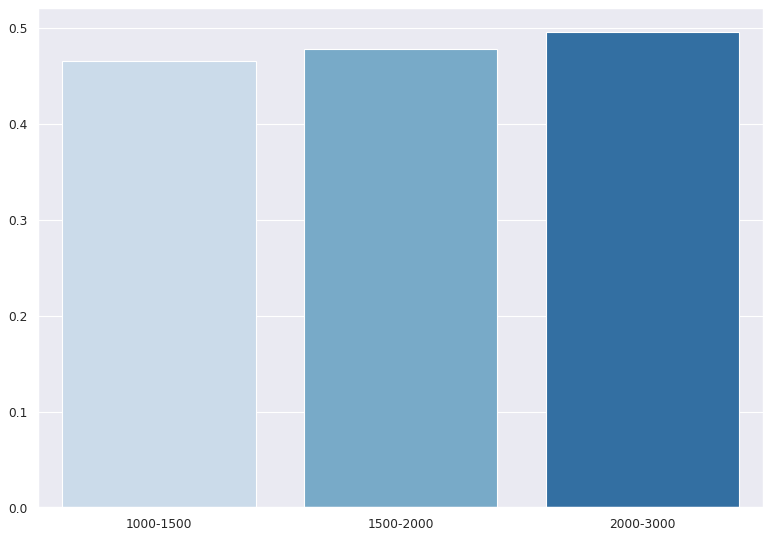

```python
# size
figure(figsize=(11.7,8.27), dpi=80)
list_2_arr = [chess2_low, chess2_mid, chess2_high]
# ratings
titles  = ["1000-1500", "1500-2000", "2000-3000"]
win_rates = []
for i in list_2_arr:
  num_wins = i['winner'].sum()
  total_gamse = i.shape[0]
  win_rates.append(num_wins/total_gamse)


sns.barplot(x = titles,
            y = win_rates,
            palette = "Blues")
plt.show()
```

## Opening ECO

Does the opening have any impact on the outcome of the game? If it does we may be able to use the starting ECO as a factor of determining wheter a player is using a chess engine or not.

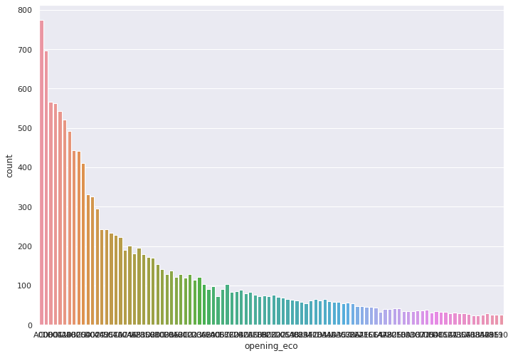

```python
chess_2_rated = chess_2[chess_2['rated'] == True]
sns.set(rc={'figure.figsize':(11.7,8.27)})
ECO_arr = chess_2['opening_eco'].value_counts().iloc[:100].index
sns.countplot(data=chess_2_rated, x="opening_eco", order=ECO_arr)
plt.show()
```

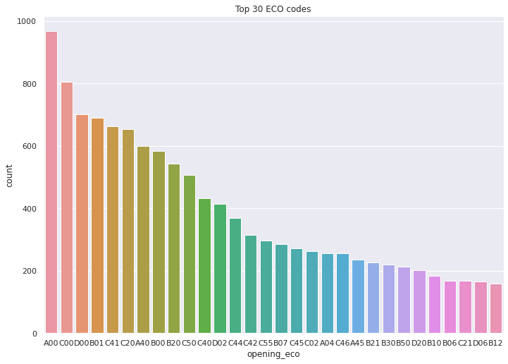

```python
sns.set(rc={'figure.figsize':(11.7,8.27)})
# Counts all the occurances of each ECO then ilocs on a range to return
# a pandas series of all the counts greatest to least indexed by the
# ECO codes
ECO_arr = chess_2['opening_eco'].value_counts().iloc[:30].index
sns.countplot(x = chess_2['opening_eco'], order=ECO_arr).set_title('Top 30 ECO codes')
```

We can see that it is not an even distribution of openings.

The second plot is much more readable and shows that the most popular openings begin with pawns that open up the center of the board. But just in the top 30 openers, the most used opener shows up five times more than the last opener. But in the context of all ECO codes in the dataset, the 30th code is in the top 10% of all openers. So given how frequently these codes appear, they might correlate with win rates.

## Does ECO effect liklihood of winning

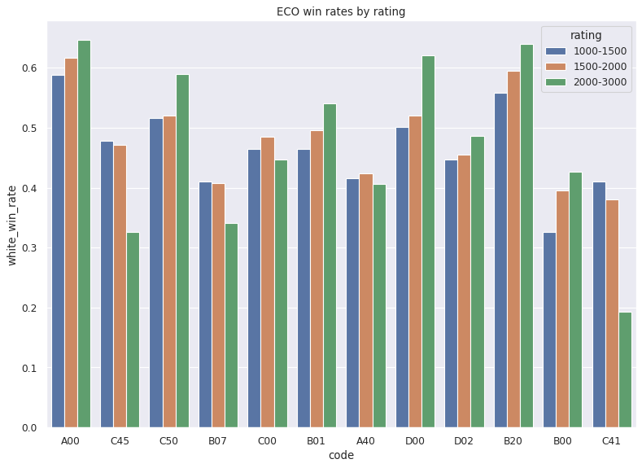

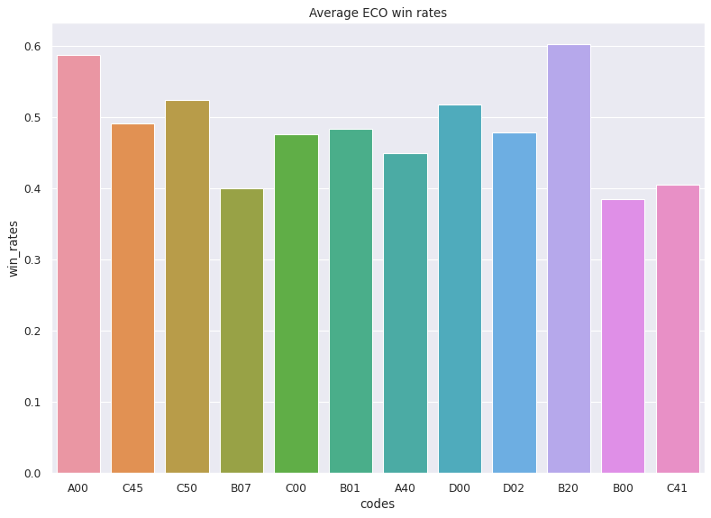

```python
#function for merging two lists
def intersection(lst1, lst2):
    return list(set(lst1) & set(lst2))

figure(figsize=(11.7,8.27), dpi=80)
# top 10 ECO
ECO_arr = intersection(
    intersection(
        (chess2_low['opening_eco'].value_counts().iloc[:20].index),
        (chess2_mid['opening_eco'].value_counts().iloc[:20].index)),
        (chess2_high['opening_eco'].value_counts().iloc[:20].index))
d = {'white_win_rate': [], 'code': [], 'rating': []}
df = pd.DataFrame(data=d)




# Goal make a df like {white_win_rate, code, rating}
list_2_arr = [chess2_low, chess2_mid, chess2_high]
titles  = ["1000-1500", "1500-2000", "2000-3000"]
count = 0
for i in list_2_arr:
  ECOs = i.groupby('opening_eco')
  for ECO, frame in ECOs:
    num_wins = frame['winner'].sum()
    total_gamse = frame.shape[0]
    rate = (num_wins/total_gamse)
    df.loc[len(df.index)]  = [rate, ECO, titles[count]]
  count = count + 1



sns.barplot(data=df,
            x="code",
            y="white_win_rate",
            hue="rating",
            order = ECO_arr).set_title('ECO win rates by rating')

plt.show()

codes = []
win_rates = []
ECOs = chess_2_rated.groupby('opening_eco')
for ECO, frame in ECOs:
  num_wins = frame['winner'].sum()
  total_gamse = frame.shape[0]
  codes.append(ECO)
  win_rates.append(num_wins/total_gamse)


figure(figsize=(11.7,8.27), dpi=80)
ax = sns.barplot(x = codes, y = win_rates, order = ECO_arr)
ax.set_title('Average ECO win rates')
ax.set(xlabel='codes', ylabel='win_rates')

plt.show()
```

From these two plots we can see that diffrent openers have diffrent average white side win rates. The upper bound seems to be around 62%, while the lower is around 42%. But these rates are highly dependent on the rating divison. For example c45 has a average win rate of 50% but when looking at for players in the 2000-3000 range the average win rate is only 35%. This intitally seems like a decent indicator since 60% is a large advantage but this is primaritly due to the number players usnig each one, many of these have low counts so I cannot make a sound conclusion, but it will be good to keep in mind. But also for refrence Stockfish's favorite opener is e4 which is the B00 ECO code, so you may assume that is a strong opener but it was one of the lowest winrates in the plot, though it does perform better with better players. But for now it does not seem like a strong metric, the dimensionality would also become an issue since i would have to one hot encode them all.

## Centipawn loss in relation to diffrence in rating

centipawn loss is the measurement of the accuracy of the entire game, of how close the moves the player made were to the engine's best move. A very high score can be interpreted as every turn the player made some of the worst moves possible. While a very low score means it's playing similarly to how the engine would have played.

In this case, where we are measuring loss in relation to rating differences, I expect the player with the lower score to have a higher loss given how when playing against a better player the worse player should be making more mistakes and play poorly in comparison.

```python
# df when white rating is higher
wht_higher1 = chess1_low[chess1_low['Black Rating'] < chess1_low['White Rating']].copy()
wht_higher2 = chess1_mid[chess1_mid['Black Rating'] < chess1_mid['White Rating']].copy()
wht_higher3 = chess1_high[chess1_high['Black Rating'] < chess1_high['White Rating']].copy()
wht_higher1['range'] = "1000-1500"
wht_higher2['range'] = "1500-2000"
wht_higher3['range'] = "2000+"
wht_higher1['diff'] = wht_higher1['White Rating'] - wht_higher1['Black Rating']
wht_higher2['diff'] = wht_higher2['White Rating'] - wht_higher2['Black Rating']
wht_higher3['diff'] = wht_higher3['White Rating'] - wht_higher3['Black Rating']

frames = [wht_higher1,wht_higher2,wht_higher3]
wht_higher = pd.concat(frames)


# df when black rating is higher
blk_higher1 = chess1_low[chess1_low['Black Rating'] > chess1_low['White Rating']].copy()
blk_higher2 = chess1_mid[chess1_mid['Black Rating'] > chess1_mid['White Rating']].copy()
blk_higher3 = chess1_high[chess1_high['Black Rating'] > chess1_high['White Rating']].copy()
blk_higher1['range'] = "1000-1500"
blk_higher2['range'] = "1500-2000"
blk_higher3['range'] = "2000+"
blk_higher1['diff'] = blk_higher1['Black Rating'] - blk_higher1['White Rating']
blk_higher2['diff'] = blk_higher2['Black Rating'] - blk_higher2['White Rating']
blk_higher3['diff'] = blk_higher3['Black Rating'] - blk_higher3['White Rating']

frames = [blk_higher1,blk_higher2,blk_higher3]
blk_higher = pd.concat(frames)

merged_higher = pd.concat([wht_higher,blk_higher])
```

```
<function matplotlib.pyplot.show(close=None, block=None)>
```

[figure not shown]

```python
figure(figsize=(11.7,8.27), dpi=80)
sns.lmplot(data=blk_higher,
                x="diff",
                y="Black Centi-pawn Loss",
                hue="range")
plt.title('Black aCPL when white rating is higher ')
plt.show
```

```
<function matplotlib.pyplot.show(close=None, block=None)>
```

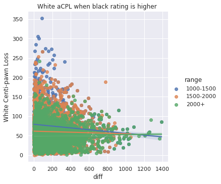

```python
figure(figsize=(11.7,8.27), dpi=80)
sns.lmplot(data=blk_higher,
                x="diff",
                y="White Centi-pawn Loss",
                hue="range")
plt.title('White aCPL when black rating is higher ')
plt.show
```

## Wins in relations to ratings

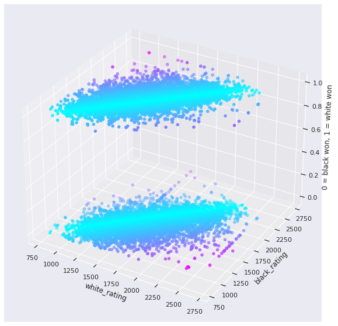

```
count    18918.000000
mean       176.108521
std        180.275411
min          1.000000
25%         47.000000
50%        118.000000
75%        246.000000
max       1605.000000
Name: diff, dtype: float64
```

```python
from mpl_toolkits.axes_grid1 import make_axes_locatable

wht_higher1 = chess_2[chess_2['black_rating'] < chess_2['white_rating']].copy()
wht_higher1['diff'] = wht_higher1['white_rating'] - wht_higher1['black_rating']

blk_higher1 = chess_2[chess_2['black_rating'] > chess_2['white_rating']].copy()
blk_higher1['diff'] = blk_higher1['black_rating'] - blk_higher1['white_rating']

diff_frame = pd.concat([wht_higher1,blk_higher1])


color_map = plt.get_cmap('cool')

# plot
plt.figure(figsize=(11,10))


axes = plt.axes(projection='3d')
axes.scatter3D(diff_frame['white_rating'],
               diff_frame['black_rating'],
               diff_frame['winner'],
               c = (diff_frame['diff']),
               cmap = color_map)
axes.set_xlabel('white_rating')
axes.set_ylabel('black_rating')
axes.set_zlabel('0 = black won, 1 = white won')
data = np.arange(2025, 0, -1).reshape(45, 45)
divider = make_axes_locatable(ax)
im = ax.imshow(data, cmap='cool')
cax = divider.append_axes('left', size='10%', pad=5)
ax.grid(False)
#fig.colorbar(im, cax=cax, orientation='vertical', label = 'Rating difference')


plt.show()
diff_frame['diff'].describe()
```

## Likelihood of making a mistake your opponent is higher rating

```
<function matplotlib.pyplot.show(close=None, block=None)>
```

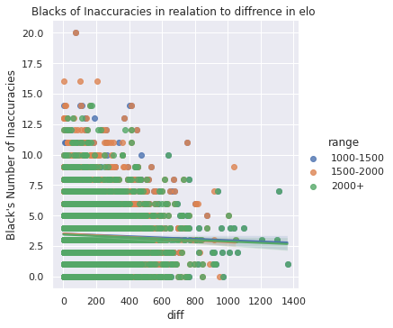

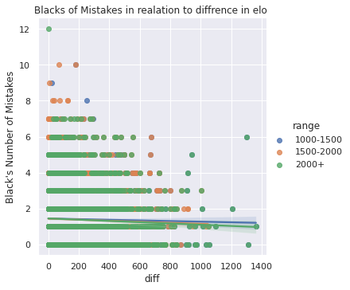

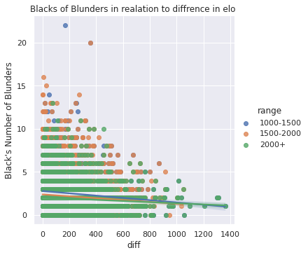

```python
figure(figsize=(11.7,8.27), dpi=80)
sns.lmplot(data=wht_higher,
                x="diff",
                y="Black's Number of Inaccuracies",
                hue="range")
plt.title('Blacks of Inaccuracies in realation to diffrence in elo ')
plt.show
figure(figsize=(11.7,8.27), dpi=80)
sns.lmplot(data=wht_higher,
                x="diff",
                y="Black's Number of Mistakes",
                hue="range")
plt.title('Blacks of Mistakes in realation to diffrence in elo ')
plt.show
figure(figsize=(11.7,8.27), dpi=80)
sns.lmplot(data=wht_higher,
                x="diff",
                y="Black's Number of Blunders",
                hue="range")
plt.title('Blacks of Blunders in realation to diffrence in elo ')
plt.show
```

This plot reinforces the claims made in the average centipawn loss visualization. The data is counterintuitive, as the gap in skill increases the chances of making any one of the three mistakes decrease instead of increasing. These plots show why the centipawn loss was so low in the games with huge gaps. But it does not explain why it occurs. Players in the 2000+ range are much less likely to make any of the mistakes, especially blunders, so given that they comprise almost all the markers beyond the 1000 rating difference means players likely near the 1000 rating are playing well if not better than players who are rated over 2000. The 2000-rated players should not be giving away free pieces, they should be doing discover checks or other tactics a lower-level player would not be able to foresee or react to.

## What dimensions matter

1. Opening side: There is a slight benefit for the player starting white but it is not significant. There is also no indicator of who may or may not be cheating. But it does show no matter what side the player is on the effect of the other features will be the same.
2. Opening ECO: No specific benefits of choosing one opener over the other, though some had higher win rates. But it cannot be used in identifying cheaters using chess engines since openers are consistent moves and only use up around three turns. Afterward is when the engine becomes useful since it can account for the entire board rather than a single pawn at e4.
3. aCPL: First useful metric, by itself, does not have much value but combined with player ratings it can show when a player is playing very well with a large skill gap. But also if a player has less than 5 aCPL there is a very high probability that they are cheating regardless of rating. This occurs because engines make moves often called "bot moves" which they interpret as the best move but it's a human would never normally make. An example would be sacrificing a queen for a tactic that would come into play 5 turns in the future.
4. difference in rating: This will be the core metric since it puts the game into perspective. aCPL alone is very consistent no matter the rating. But as the difference in rating changes, the other stats should trend negatively, unless they are much better than their rating or they are cheating.
5. the number of mistakes: similar to aCPL, but better players will make fewer mistakes than lower-rated players. As the rating gap increases not only does the data become more scarce in the few games that show up it seems like the number of mistakes made by the lower-rated player also decreases. this is because of the matchmaking system.
6. winning: Just like aCPL and # mistakes, this is highly dependent on the rating difference. Best represented by the 3D scatter we saw that most games were played within a certain range of rating with a similar likelihood of winning and losing but there were a few outliers that created suspicious markers.

### Matchmaking system

The lichess matchmaking system will attempt to match players of a 300 elo diffrence and have not played against each other in a session, if such a match is not found it will broaden the results. The issue is that when you perform really well it will attempt to lessen the diffrence and match you against better players, but this does not happen frequently which shows how good the rating system. And as an unintended benefit it creates very obvious outliers, wheter thay are cheating or they are making a new account of somthing along those lines cannot be decided without further analysis.

# Predicting the Cheater

After the data analysis I found the the most significant features for finding outliers are: player rating, winner, and aCPL. With these features i beleive that i can make a high dimensional classifiaction algorithm to classify cheaters from normal players. Naturally this will be a nonsupervised since none of the datasets contain a feature for this, but my workaround is searcing for the player in the API and seeing if they were banned or not.

```python
from sklearn.cluster import DBSCAN
from sklearn.cluster import KMeans
from sklearn import metrics
from sklearn.preprocessing import power_transform
from sklearn.neighbors import NearestNeighbors
from sklearn.preprocessing import MinMaxScaler

from sklearn.model_selection import train_test_split
from sklearn.preprocessing import StandardScaler


print(client.users.get_by_id('bourgris')[0])
print((client.users.get_by_id('bourgris'))[0].get('disabled'))
print(client.users.get_by_id('burks')[0])
print((client.users.get_by_id('burks'))[0].get('disabled'))
```

```
{'id': 'bourgris', 'username': 'bourgris', 'perfs': {'blitz': {'games': 0, 'rating': 1500, 'rd': 500, 'prog': 0, 'prov': True}, 'puzzle': {'games': 23226, 'rating': 1906, 'rd': 65, 'prog': 0}, 'bullet': {'games': 0, 'rating': 1500, 'rd': 500, 'prog': 0, 'prov': True}, 'correspondence': {'games': 1, …
None
{'id': 'burks', 'username': 'Burks', 'disabled': True}
True
```

As you can see this is a case where we have a 2 players one is banned while the other is still active. I know if a player has been banned or not if .get('disabled') retruns True and not None.

## The models

I will be primarily looking clustering algoritms. As for what type of clustering, I will be testing both centroid and density based clustering. So the algorithms i will be using will be [k means](https://towardsdatascience.com/understanding-k-means-clustering-in-machine-learning-6a6e67336aa1) and density based clustering([DBSCAN](https://www.geeksforgeeks.org/dbscan-clustering-in-ml-density-based-clustering/))

### Preparing data

```python
# we only want serious games
diff_frame = diff_frame[diff_frame['rated'] == True]
# These cols will not be used
# diff is needed but it provides no info on who has the advantage
# But i want to force rank diffrence as a feature in the model
diff_frame = diff_frame.drop(['victory_status','opening_eco','rated'], axis =1)
```

### Preparing test, model comparsison training, and data ([Train/Dev/Test Split](https://snji-khjuria.medium.com/everything-you-need-to-know-about-train-dev-test-split-what-how-and-why-6ca17ea6f35))

```python
# Creating training set and set that will be split into test and dev
train, part = train_test_split(diff_frame,
                               test_size=0.3,
                               random_state = 10,
                               shuffle = True)
# Not calling it dev cuz its confusing
comp, test = train_test_split(part,
                              test_size = 0.3,
                              random_state = 10,
                              shuffle = True)
print("Training size", len(train))
print("Model rating size", len(comp))
print("Final testing size", len(test))
```

```
Training size 10745
Model rating size 3224
Final testing size 1382
```

```python
train_data = train.loc[:,['winner', "white_rating", 'black_rating','diff']]
comp_data = comp.loc[:,['winner', "white_rating", 'black_rating','diff']]
test_data = test.loc[:,['winner', "white_rating", 'black_rating','diff']]
```

### [Preparing the data to be symetric](https://medium.com/@evgen.ryzhkov/5-stages-of-data-preprocessing-for-k-means-clustering-b755426f9932)

First i will be do a transformation on the data to make it more like a normal distribution. This is needed to fit the data into the model.

```python
scaler = StandardScaler()
X_train = scaler.fit_transform(train_data)
X_dev = scaler.transform(comp_data)
X_test = scaler.transform(test_data)

## Method 2
scaler = MinMaxScaler()
columns = train_data.columns
train_data[columns] = scaler.fit_transform(train_data[columns])
```

## K-Means clustering

Params

1. number of clusters
2. Method for initialization:
   1. ‘k-means++’ : selects initial cluster centroids using sampling based on an empirical probability distribution of the points’ contribution to the overall inertia.
   2. ‘random’: choose n_clusters observations (rows) at random from data for the initial centroids.
3. random_state: Determines random number generation for centroid initialization.

### Finding the elbow

```
1 Clusters: 42980.0000
2 Clusters: 30852.1580
3 Clusters: 23683.2104
4 Clusters: 19095.5695
5 Clusters: 15556.5139
6 Clusters: 13023.0044
7 Clusters: 11521.1193
8 Clusters: 10124.8155
9 Clusters: 9415.0842
```

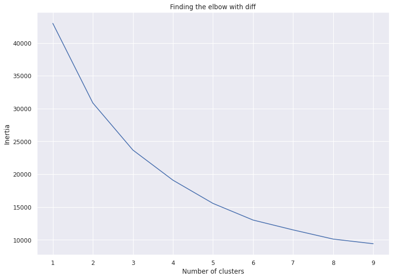

```python
#the min and max number of clusters avalible for kmeans
# loop to find the best elbow
ks = range(1, 10)
# list for tracking inertia
inertias = []
for k in ks:
    model = KMeans(n_clusters=k, init='k-means++', random_state = 10)

    model.fit(X_train)

    inertias.append(model.inertia_)
    print('%i Clusters: %0.4f' % (k, model.inertia_))

figure(figsize=(11.7,8.27), dpi=80)
sns.lineplot(ks, inertias)
plt.xlabel('Number of clusters')
plt.ylabel('Inertia')
plt.title('Finding the elbow with diff')



plt.show()
```

This line plot does not have a very defined elbow point. I am interpreting it at 4. But given how ambiguous the elbow point is either k-means might not be the algorithm I want to be using or I need to change the dimensions. Generally in my testing i found that too many dimensions causes similar problems, or when the data is heavilly related. But for now, I will be continuing the training to see the output.

```python
# K means clustering of Training Data
kmeans = KMeans(n_clusters = 4, init = 'k-means++', n_init = 10, random_state = 10)
kmeans.fit(X_train)
labels = kmeans.labels_
```

```
<function matplotlib.pyplot.show(close=None, block=None)>
```

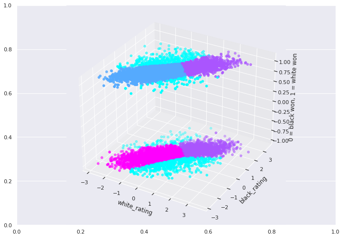

```python
df = pd.DataFrame(X_train)
df['cluster'] = pd.Series(labels, index=df.index)

#Rename Cluster label names from k-means
cluster_label_names = {0: "1", 1: "2", 2: "3", 3: "4", 4: "5"}
df['groupings'] = df['cluster'].map(cluster_label_names)

df.columns = ["winner","white_rating", 'black_rating','diff', 'Cluster', 'groupings']

# Plots of Win Ratio, Kill Death Ratio, Headshott KIll Ratio
color_map = plt.get_cmap('cool')

# plot
plt.figure(figsize=(11,10))
fig, ax = plt.subplots()


axes = plt.axes(projection='3d')
axes.scatter3D(df['white_rating'],
               df['black_rating'],
               df['winner'],
               c = (df['Cluster']),
               cmap = color_map)
axes.set_xlabel('white_rating')
axes.set_ylabel('black_rating')
axes.set_zlabel('0 = black won, 1 = white won')
plt.show
```

To fix it we need to allow it to generalize more but fewer clusters make it work even worse. And changing the features such as removing diff also makes the model fail since it no longer cares for the differences in elo. As of right now it seems like this model is a poor choice in for this problem.

```python
print(df.groupby('groupings').count())
```

```
           winner  white_rating  black_rating  diff  Cluster
groupings
1            1158          1158          1158  1158     1158
2            3313          3313          3313  3313     3313
3            2802          2802          2802  2802     2802
4            3472          3472          3472  3472     3472
```

For now, let us try DBSCAN. In this situation, DBSCAN may be very powerful due to how it performs clustering.

### A very top-level explanation

The algorithm has starting points from those points it checks all the surrounding points, if those points meet a certain threshold in quantity and distance, it calls itself a core node. These nodes are what make up the cluster, once all of the core nodes are found we are left with the non-core points. These points can be added to the cluster if they meet the distance requirement but they cannot be used for extending the cluster. Everything else is left unclustered as an outlier.

This seems like it would work perfectly in my use case since it will hopefully be able to identify the two large clusters while excluding the outliers which I'm hoping are the cheaters.

## DBSCAN

### [Parameter Estimation](https://medium.com/@tarammullin/dbscan-parameter-estimation-ff8330e3a3bd)

The general rule of thumb for choosing the min_samples is to multiply the dimensionality of the input by 2. It should also be noted there are some other cases where you want to increase the min_samples which are: large datasets and noisy data. My data does not satisfy either of those so I'm going to stick to min_samples = 2*dim.

### Finding the min distance(eps)

Treat the distance as the radius around the point, we want to see if any points are within that radius. I will be finding the average distance between points using the min_samples nearest neighbors.

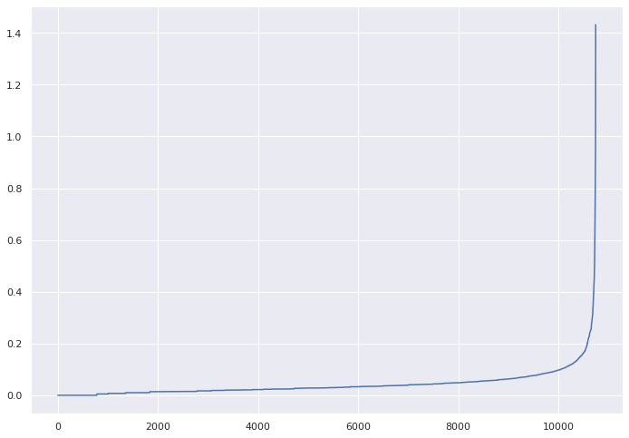

```python
neighbors = NearestNeighbors(n_neighbors=8)
neighbors_fit = neighbors.fit(X_train)
distances, indices = neighbors_fit.kneighbors(X_train)
distances = np.sort(distances, axis=0)
distances = distances[:,1]
plt.plot(distances)
```

The plot tells the 8-NN distance in respect to sample size, with the y-axis describing the 8-NN distance and the x-axis is the number of samples. so we want to find the distance where we can get good clustering but not overfit. From this we can approximate the knee of the plot is around .3, but since i want only around 2 clusters i want the distance to be slightly larger to make sure the outliers are very explicit and defined. To acheive this i will be checking the results from 3.0 to 3.5. This will be the maximum since any higher the clusters will be too large and overfit and if any lower it will result in too many clusters.

### Get banned method

This is used after the model has been trained to see how successful the model was in finding the cheaters. Due to limitations i cannot check for all the cheaters in any of the datasets, instead the use will be limited to the results of model. As a consequence this will only tell me the precison of the results but provide no info on the recall.

```python
def get_banned(df):
  cheaters = []
  for idx, row in df.iterrows():
    if ((client.users.get_by_id(row['white_id']))[0].get('disabled') == True) :
        cheaters.append(row['white_id'])
    if ((client.users.get_by_id(row['black_id']))[0].get('disabled') == True) :
        cheaters.append(row['white_id'])
  return cheaters
```

## Training the model

```
.30 Eps:
Cluster
-1    377
Name: Cluster, dtype: int64
.31 Eps:
Cluster
-1    351
Name: Cluster, dtype: int64
.32 Eps:
Cluster
-1    320
Name: Cluster, dtype: int64
.33 Eps:
Cluster
-1    290
Name: Cluster, dtype: int64
.34 Eps:
Cluster
-1    264
Name: Cluster, dtype: int64
```

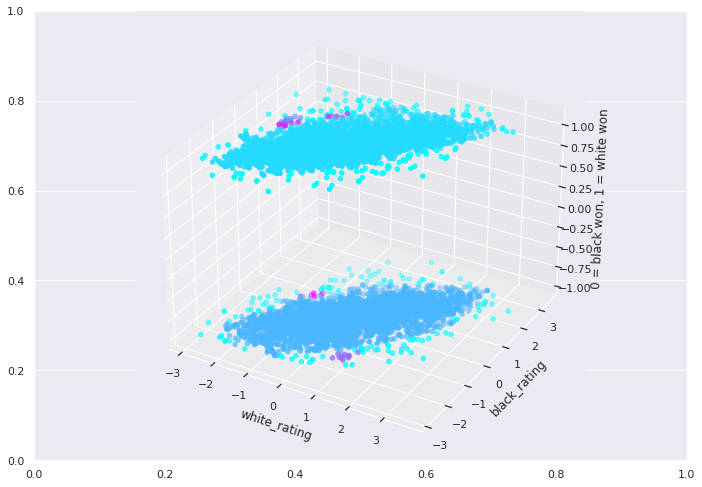

```python
for x in range(30,35):
  dbscan = DBSCAN(eps=(x/100), min_samples= 8, algorithm = 'ball_tree')
  dbscan.fit(X_train)
  labels = dbscan.labels_
  df = pd.DataFrame(X_train)
  df['cluster'] = pd.Series(labels, index=df.index)
  cluster_label_names = {-1: "CHEATERS", 1: "2", 2: "3", 3: "4", 4: "5"}
  df.columns = ["winner","white_rating", 'black_rating','diff', 'Cluster']
  print('.%i Eps:' % x)
  print(df[df['Cluster'] == -1].groupby('Cluster')['Cluster'].count())





## From the counts i feel that .34 is an appropiate eps
dbscan = DBSCAN(eps=(.34), min_samples= 8, algorithm = 'ball_tree')
dbscan.fit(X_train)
labels = dbscan.labels_
df = pd.DataFrame(X_train)
df['cluster'] = pd.Series(labels, index=df.index)
#Rename Cluster label name
cluster_label_names = {-1: "CHEATERS", 1: "2", 2: "3", 3: "4", 4: "5"}
df.columns = ["winner","white_rating", 'black_rating','diff', 'Cluster']

# Plots of Win Ratio, Kill Death Ratio, Headshott KIll Ratio
color_map = plt.get_cmap('cool')

# plot
plt.figure(figsize=(11,10))
fig, ax = plt.subplots()


axes = plt.axes(projection='3d')
axes.scatter3D(df['white_rating'],
               df['black_rating'],
               df['winner'],
               c = (df['Cluster']),
               cmap = color_map)
axes.set_xlabel('white_rating')
axes.set_ylabel('black_rating')
axes.set_zlabel('0 = black won, 1 = white won')
```

```python
print(df.groupby('Cluster').count())
possible_cheaters  = df[df['Cluster'] == -1].index
```

```
         winner  white_rating  black_rating  diff
Cluster
-1          264           264           264   264
 0         4968          4968          4968  4968
 1         5465          5465          5465  5465
 2           11            11            11    11
 3           13            13            13    13
 4            8             8             8     8
 5            9             9             9     9
 6            7             7             7     7
```

This took way too long, for only 264 rows it took around 20 minutes to complete the request

```python
weird_plrs = diff_frame.iloc[possible_cheaters].sort_values('diff', ascending = False)
conf_cheaters = get_banned(weird_plrs)
conf_cheaters
```

```
['samuelpro',
 'fischerdipper',
 'chicago_chess',
 'dediraut',
 'thehaleguathor',
 'chesskhovtsev',
 'chessfan1',
 'mr_zilgaze',
 'arda2828',
 'mahmoud_safyan',
 'shivangithegenius',
 'vovkakuz',
 'chessmolester',
 'adatene',
 'elvispy65',
 'donidali',
 'fischerdipper',
 'gelus',
 'urst',
 'erik_manukyan',
 'mahmoud_safyan',
 'danielmop',
 'moistvonlipwig',
 'nimanimanima',
 'leeducdaica',
 'lechalll1',
 'lechalll1',
 'andrea78',
 'rustam9',
 'aka121',
 'b4rb',
 'nuffsaidm8',
 'aerdna87',
 'tony995',
 'yazeed_bani_saleem',
 'yazeed_bani_saleem',
 'kilro',
 'komis1987',
 'kevchod',
 'andreas00',
```

[output cut: 13 more lines]

```
 'phileasfrog',
 'nitzs',
 'laguigne',
 'laguigne',
 'siomka_gio',
 'y_d',
 'a_p_t_e_m_u_u',
 'a_p_t_e_m_u_u',
 'chesskhovtsev',
 'manish_007',
 'wiggleitjiggleit',
 'toya83',
 'toya83',
 'userx100',
 'yotastrejos']
```

### Comments on cheating

First, just because one of the players that have not been banned does not imply that they did not cheat in that specific game. Im not sure for lichess but i know many algorithms need multiple instances of games to make an actual verdict. But on the other end of the stick some of the players that have been banned might have tirggered somthing in their system without ever cheating. Finally this model will not care whatsoever if the elo are close together. The thing is as people keep on cheating they will play against better players then it would raise a flag but before that the model would see them as a valid player

### Testing both models

```python
#Predicting on K-means
kmeans_dev = pd.DataFrame(X_test)
results = kmeans.predict(X_test)
kmeans_dev['clusters'] = results



#predicting on DBSCAN
# note that there are no prediction methods (That i could find for dbscan)
# So i will instead be retraining on the dataset, which defeats the purpose
# but i could not think of another method.
dbscan_dev = pd.DataFrame(X_test)
dbscan = DBSCAN(eps=(.34), min_samples= 8, algorithm = 'ball_tree')
dbscan.fit(X_test)
labels = dbscan.labels_
dbscan_dev['cluster'] =labels
```

```python
dbscan_possible_cheaters  = dbscan_dev[dbscan_dev['cluster'] == -1].index
weird_plrs1 = diff_frame.iloc[dbscan_possible_cheaters].sort_values('diff', ascending = False)
kmeans_possible_cheaters  = kmeans_dev[kmeans_dev['clusters'] == 1].index
weird_plrs2 = diff_frame.iloc[kmeans_possible_cheaters].sort_values('diff', ascending = False)
dbscan_conf_cheaters = get_banned(weird_plrs1)
kmeans_conf_cheaters = get_banned(weird_plrs2)
```

```python
print(len(weird_plrs1))
print(len(dbscan_conf_cheaters))
print(dbscan_conf_cheaters/weird_plrs1)

print(len(weird_plrs2))
print(len(kmeans_conf_cheaters))
print(kmeans_conf_cheaters/weird_plrs1)
```

[output not shown]

Since we have seen that overall DBSCAN performs much better than Kmeans it still performs poorly, And our elvaluation of the models have not been very rigourous. To evaluate dbscan we are pretty limited to functions and methods that evaluate the clustering ability of out model. To do this clustering analysis i will be using the Mean Silhouette Coefficien, it is bounded by [-1,1] the better the clustering the closer it will be to one so a middle of the road model will score around zero.

```python
metrics.silhouette_score(dbscan_dev, dbscan_dev['cluster'])
```

```
0.24286164857033513
```

From this score i can see that my model's clustering ability is not bad but also not good, it seems very average. But what this means is there is not allot of overlapping clusters or mislabeled points which is very good to see. But like previously said it provides no metric on how well it is at discovering cheaters since even i dont know all the info.

## Final remarks

- Without provided labels on banned players these models are very difficult to evaluate. We have no notion of what the accuracy will be, but with the provided details we hope that we were able to make an educated guess on how good the clusters were good at predicting cheaters.
- As stated prior it is almost impossible to accurately predict cheaters with this much info, to put in perspective you can view lichess's cheating algorithm here Though somthing like this would be replicable it shows how much more detail goes into it. It is actually really interesting , if your interested it's open sourse and on github.
- the model may be improved with more tuning, some ideas i have are,
  - Changing the distance or doing more expreiments on the distance and neighborhood requirments.
  - Changing the dimensions/features of the dataset, it wont be a bad idea to include both players centipawn loss, but i fear it would create noise.

# Conclusion